# 331 project visualizations

Markelle Kelly

5/16/2018

```r
library(ggplot2)
library(scales)
setwd("/Users/markelle/Desktop/STAT 331/project")
data <- read.csv("featuresdf.csv")
```

# Plot 1

One plot we could add to our app is a density plot of a quantitative variable, divided by genre. Users would be able to customize which quantitative variable (of danceability, energy, loudness, speechiness, acousticness, instrumentalness, liveness, and valence) to plot, and select which genres they would like plotted. Below are three examples of customized density plots.

#### This first plot selects all genres except soundtrack and country, and plots their energy.

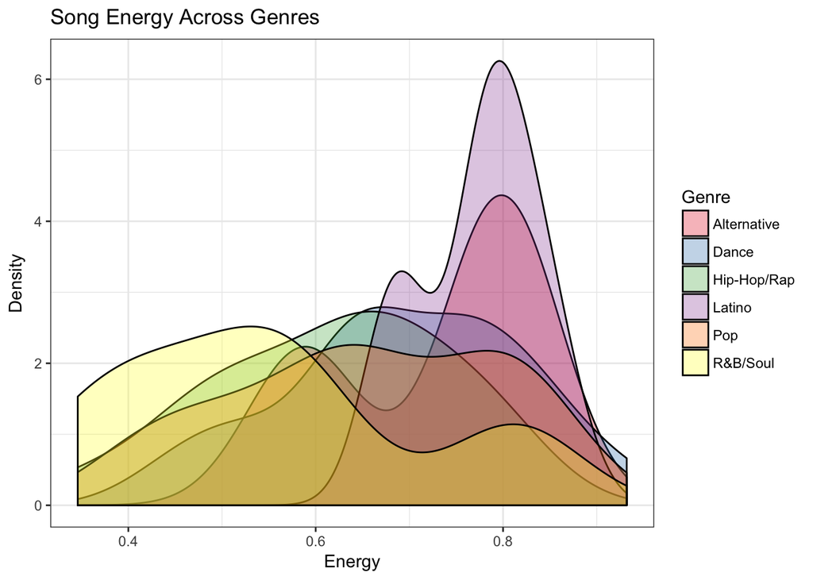

```r
subset <- data[data$genre != "Soundtrack" & data$genre != "Country",]
g2 <- ggplot(subset, aes(energy)) + geom_density(aes(fill=factor(genre)), alpha=0.3) +
  labs(title="Song Energy Across Genres", x="Energy",y="Density",fill="Genre") +
  theme_bw() +
  scale_fill_brewer(palette = "Set1")
g2
```

#### This second plot looks at valence for the dance, hip-hop/rap, latino, and pop genres.

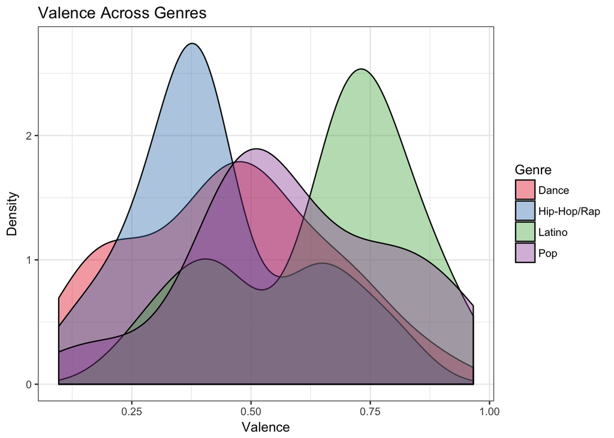

```r
subset2 <- subset[subset$genre != "Alternative" & subset$genre != "R&B/Soul",]
g3 <- ggplot(subset2, aes(valence)) + geom_density(aes(fill=factor(genre)), alpha=0.4) +
  labs(title="Valence Across Genres", x="Valence",y="Density",fill="Genre") +
  theme_bw() +
  scale_fill_brewer(palette = "Set1")
g3
```

#### Finally, this third plot looks at acousticness for alternative, dance, latino, and r&b/soul songs.

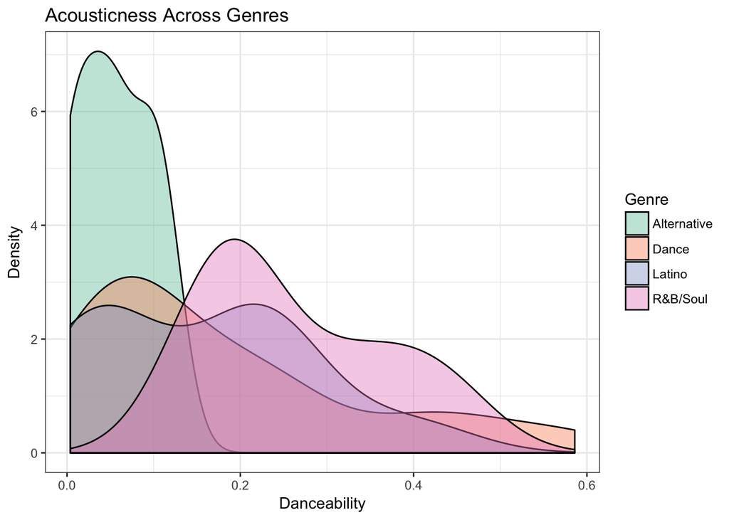

```r
subset3 <- subset[subset$genre != "Pop" & subset$genre != "Hip-Hop/Rap",]
g4 <- ggplot(subset3, aes(acousticness)) + geom_density(aes(fill=factor(genre)), alpha=0.4) +
  labs(title="Acousticness Across Genres", x="Danceability",y="Density",fill="Genre") +
  theme_bw() +
  scale_fill_brewer(palette = "Set2")
g4
```

```r
data$mode[data$mode == 0] = "Minor"
data$mode[data$mode == 1] = "Major"

dataMinor = data[data['mode']=="Minor",]
dataMajor = data[data['mode']=="Major",]
```

# Plot 2

Users of the applet will be able to select x and y variables from the following list: - loudness - energy - valence - tempo This selection will produce a scatter plot of the data as well as fit a linear model and display its equation.

Furthermore, users will be able to decide whether to look at a plot of all of the data or have two plots, split by mode (major or minor key).

#### The following plot would be the result of the user selecting x = Energy, y = Loudness, and to split the plots by mode.

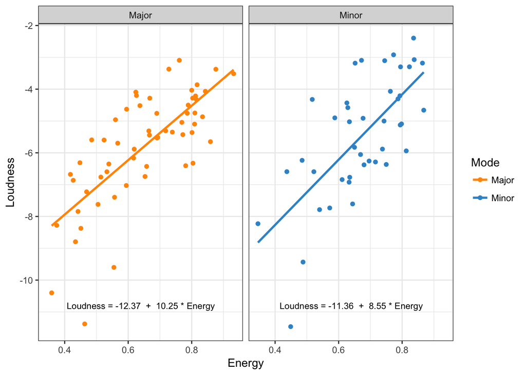

```r
lm1 = lm(formula = dataMinor$loudness~dataMinor$energy)
formula1 = paste("Loudness =",round(unname(lm1$coefficients[1]),2), " + ", round(unname(lm1$coefficients[2]),2), "* Energy")

lm2 = lm(formula = dataMajor$loudness~dataMajor$energy)
formula2 = paste("Loudness =",round(unname(lm2$coefficients[1]),2), " + ", round(unname(lm2$coefficients[2]),2), "* Energy")

ggplot(data = data, aes(x = energy, y = loudness)) +
  geom_point(data = data, aes(color = mode)) +
  facet_grid(.~mode) +
  labs(x = "Energy", y = "Loudness", color = "Mode") +
  theme_bw() +
  geom_smooth(method = "lm", data = data, aes(color = mode), se = F) +
  scale_color_manual(values = c("#ff9707", "#3995ce")) +
  annotate("text", label = c(formula1, formula2), x = 0.64, y = -10.8, size = 3)
```

#### The following plot would be the result of the user selecting x = Energy, y = Loudness, and to not split the plots by mode.

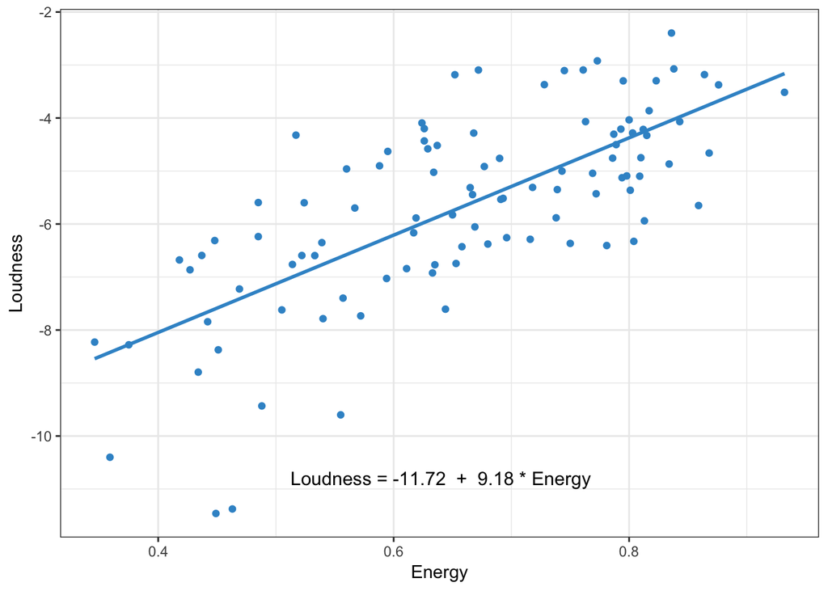

```r
lm = lm(formula = data$loudness~data$energy)
formula = paste("Loudness =",round(unname(lm$coefficients[1]),2), " + ", round(unname(lm$coefficients[2]),2), "* Energy")

ggplot(data = data, aes(x = energy, y = loudness)) +
  geom_point(data = data, color = "#3995ce") +
  labs(x = "Energy", y = "Loudness") +
  theme_bw() +
  geom_smooth(method = "lm", data = data, se = F, color = "#3995ce") +
  annotate("text", label = formula, x = 0.64, y = -10.8, size = 4)
```

#### The following plot would be the result of the user selecting x = Energy, y = Valence, and to split the plots by mode.

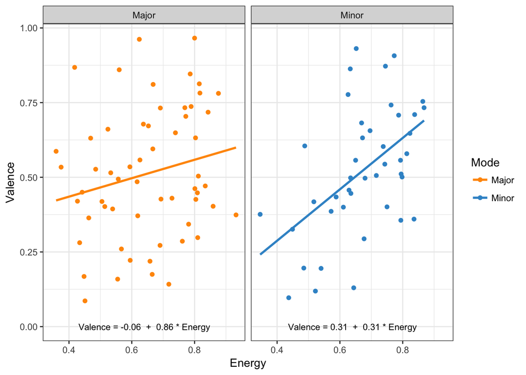

```r
lm1 = lm(formula = dataMinor$valence~dataMinor$energy)
formula1 = paste("Valence =",round(unname(lm1$coefficients[1]),2), " + ", round(unname(lm1$coefficients[2]),2), "* Energy")

lm2 = lm(formula = dataMajor$valence~dataMajor$energy)
formula2 = paste("Valence =",round(unname(lm2$coefficients[1]),2), " + ", round(unname(lm2$coefficients[2]),2), "* Energy")

ggplot(data = data, aes(x = energy, y = valence)) +
  geom_point(data = data, aes(color = mode)) +
  facet_grid(.~mode) +
  labs(x = "Energy", y = "Valence", color = "Mode") +
  theme_bw() +
  geom_smooth(method = "lm", data = data, aes(color = mode), se = F) +
  scale_color_manual(values = c("#ff9707", "#3995ce")) +
  annotate("text", label = c(formula1, formula2), x = 0.64, y = 0, size = 3)
```

# Plot 3

This plot will allow users to view the different variables based on genre. Users will be able to choose which categorical variable they wish to see the count of, whether it be artists with more than one top song or the number of female/males with top songs. They are all color coded based on the genre the song belongs to. Below are examples of three views. #### This view displays the count of top songs for artists that have multiple top songs, as well as which genre these belong to.

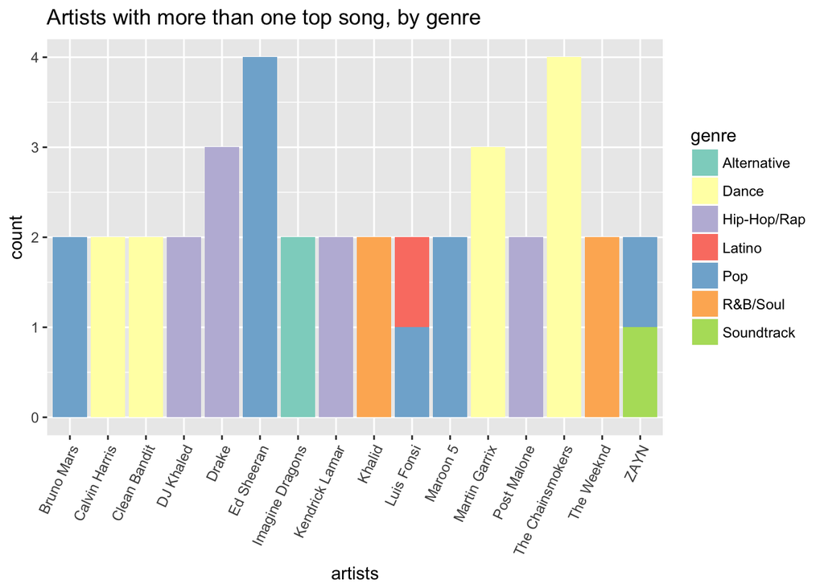

```r
subset = subset(data,data$artists %in% names(tapply(data$id, data$artists, length)[tapply(data$id, data$artists, length) > 1]))

ggplot(subset, aes(artists)) +
  geom_bar(aes(fill = genre)) +
  ggtitle("Artists with more than one top song, by genre") +
  theme(axis.text.x=element_text(angle=65,hjust=1)) +
  scale_fill_brewer(palette = "Set3")
```

#### This view displays the count of male vs.female top artists and which genre their song belonged to.

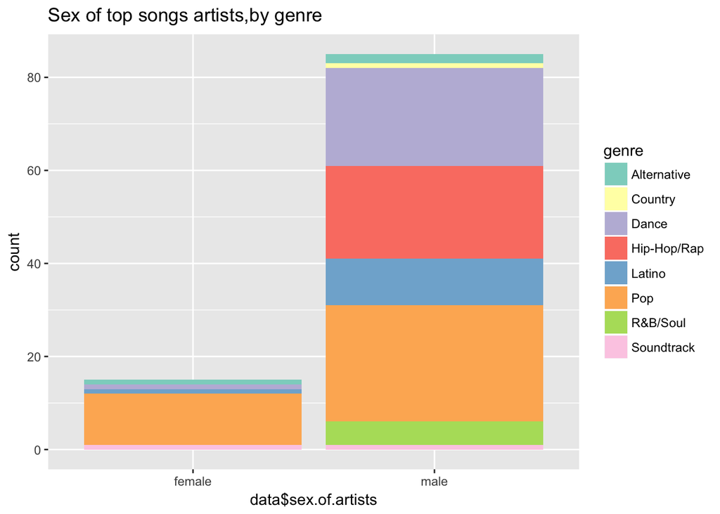

```r
ggplot(data, aes(x = data$sex.of.artists)) +
  geom_bar(data=data, aes(fill = genre)) +
  ggtitle("Sex of top songs artists,by genre") +
  scale_fill_brewer(palette = "Set3")
```

#### This view, allows the user to visualize which genre has the most number of top songs.

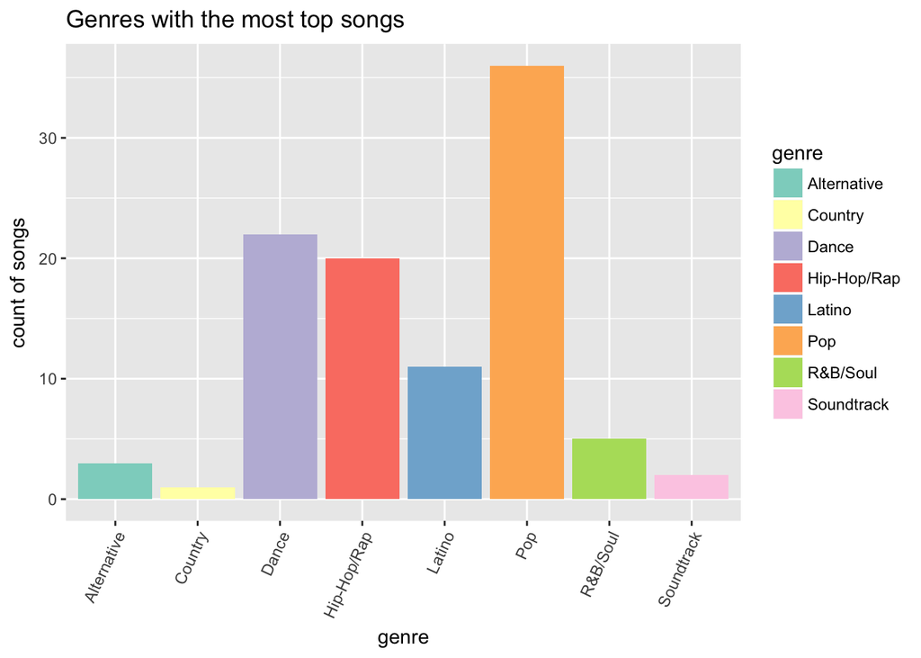

```r
ggplot(data, aes(x = data$genre)) +
  geom_bar(aes(fill = genre)) +
  ggtitle("Genres with the most top songs") +
  theme(axis.text.x=element_text(angle=65,hjust=1)) +
  scale_fill_brewer(palette = "Set3") + labs(x= "genre", y = "count of songs")
```